# EcoPower: Machine Learning Optimization of Aircraft APU Usage

```python
# Import all necessary Python packages
import pandas as pd
import numpy as np
import matplotlib.pyplot as plt
import seaborn as sns

from sklearn.model_selection import train_test_split, RandomizedSearchCV
from sklearn.preprocessing import StandardScaler, OneHotEncoder
from sklearn.compose import ColumnTransformer
from sklearn.pipeline import Pipeline
from sklearn.metrics import mean_absolute_error, mean_squared_error, accuracy_score, classification_report
from sklearn.ensemble import RandomForestRegressor, GradientBoostingRegressor, RandomForestClassifier
from sklearn.linear_model import Ridge

import xgboost as xgb
import lightgbm as lgb
import shap
import gradio as gr
import joblib
```

```python
import warnings
warnings.filterwarnings("ignore")
```

```python
import pandas as pd
df = pd.read_csv("ecopower_apu_data.csv")
df.head()
```

|  | Aircraft | Airport | Temperature | Humidity | WindSpeed | ScheduleTime | InfraType | UsedAPUMin | Emissions_CO2 |
| --- | --- | --- | --- | --- | --- | --- | --- | --- | --- |
| 0 | A350 | SEA | 17.015129 | 43.914067 | 9.428424 | 96 | Moderate | 23.178949 | 42.68 |
| 1 | B787 | SEA | 8.048478 | 32.801869 | 10.874123 | 72 | Moderate | 41.822726 | 73.04 |
| 2 | A320 | SEA | 17.938896 | 86.711315 | 10.981226 | 152 | Advanced | 36.754313 | 76.37 |
| 3 | A350 | SEA | 24.567369 | 48.824116 | 10.463946 | 51 | Advanced | 20.926946 | 42.50 |
| 4 | A350 | ATL | 22.688150 | 56.555341 | 11.483567 | 116 | Advanced | 41.952257 | 82.75 |

## Step 1: Exploratory Data Analysis (EDA)

```python
df.describe()
```

|  | Temperature | Humidity | WindSpeed | ScheduleTime | UsedAPUMin | Emissions_CO2 |
| --- | --- | --- | --- | --- | --- | --- |
| count | 5000.000000 | 5000.000000 | 5000.000000 | 5000.000000 | 5000.000000 | 5000.000000 |
| mean | 19.907833 | 59.904157 | 10.083952 | 104.516400 | 40.069398 | 80.133582 |
| std | 5.098923 | 17.517951 | 3.034442 | 43.074628 | 9.926725 | 21.394620 |
| min | 0.816722 | 30.009465 | -0.905601 | 30.000000 | 0.322886 | -1.880000 |
| 25% | 16.502392 | 44.571130 | 8.018806 | 67.000000 | 33.055772 | 65.337500 |
| 50% | 19.899957 | 59.493139 | 10.101157 | 105.000000 | 40.099832 | 79.810000 |
| 75% | 23.374027 | 75.536734 | 12.148010 | 142.000000 | 46.661833 | 94.490000 |
| max | 37.645276 | 89.995490 | 23.437253 | 179.000000 | 75.058714 | 161.440000 |

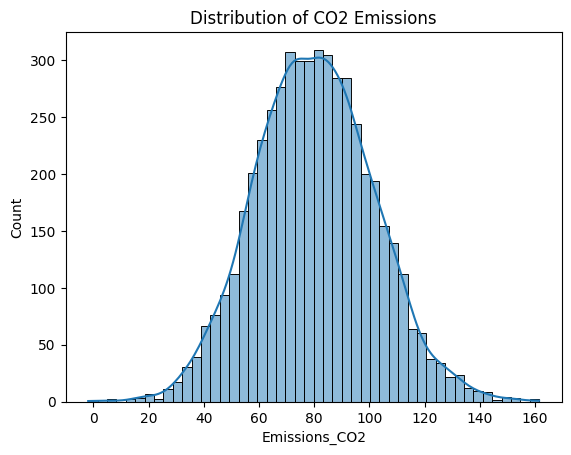

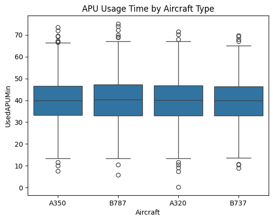

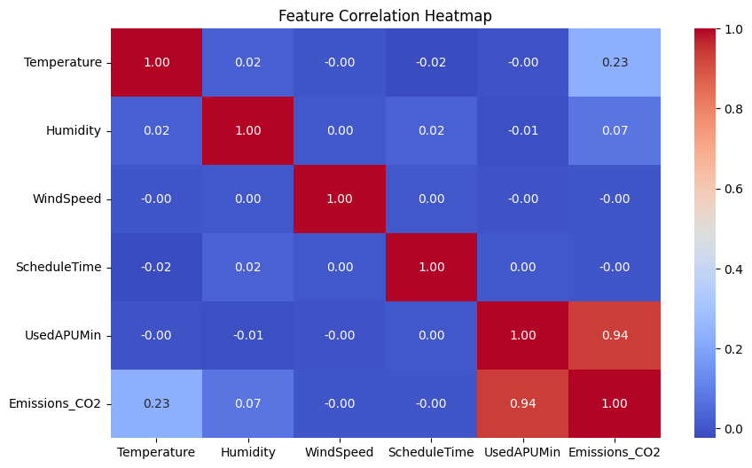

```python
import seaborn as sns
import matplotlib.pyplot as plt

sns.histplot(df['Emissions_CO2'], kde=True)
plt.title('Distribution of CO2 Emissions')
plt.show()

sns.boxplot(x='Aircraft', y='UsedAPUMin', data=df)
plt.title('APU Usage Time by Aircraft Type')
plt.show()


plt.figure(figsize=(10, 6))
sns.heatmap(df.corr(numeric_only=True), annot=True, fmt=".2f", cmap="coolwarm")
plt.title("Feature Correlation Heatmap")
plt.show()
```

## Step 2: Feature Engineering

```python
df['EfficiencyRatio'] = df['Emissions_CO2'] / df['UsedAPUMin']
df['TempHumidityIndex'] = df['Temperature'] * df['Humidity']
df.head()
```

|  | Aircraft | Airport | Temperature | Humidity | WindSpeed | ScheduleTime | InfraType | UsedAPUMin | Emissions_CO2 | EfficiencyRatio | TempHumidityIndex |
| --- | --- | --- | --- | --- | --- | --- | --- | --- | --- | --- | --- |
| 0 | A350 | SEA | 17.015129 | 43.914067 | 9.428424 | 96 | Moderate | 23.178949 | 42.68 | 1.841326 | 747.203501 |
| 1 | B787 | SEA | 8.048478 | 32.801869 | 10.874123 | 72 | Moderate | 41.822726 | 73.04 | 1.746419 | 264.005127 |
| 2 | A320 | SEA | 17.938896 | 86.711315 | 10.981226 | 152 | Advanced | 36.754313 | 76.37 | 2.077851 | 1555.505282 |
| 3 | A350 | SEA | 24.567369 | 48.824116 | 10.463946 | 51 | Advanced | 20.926946 | 42.50 | 2.030874 | 1199.480046 |
| 4 | A350 | ATL | 22.688150 | 56.555341 | 11.483567 | 116 | Advanced | 41.952257 | 82.75 | 1.972480 | 1283.136042 |

## Step 3: Data Preprocessing

```python
from sklearn.model_selection import train_test_split
from sklearn.preprocessing import StandardScaler, OneHotEncoder
from sklearn.compose import ColumnTransformer
from sklearn.pipeline import Pipeline

df['HighEmissionFlag'] = (df['Emissions_CO2'] > 75).astype(int)
X = df.drop(columns=['Emissions_CO2', 'HighEmissionFlag'])
y = df['Emissions_CO2']
y_class = df['HighEmissionFlag']

categorical = ['Aircraft', 'Airport', 'InfraType']
numerical = ['Temperature', 'Humidity', 'WindSpeed', 'ScheduleTime', 'UsedAPUMin', 'EfficiencyRatio', 'TempHumidityIndex']

preprocessor = ColumnTransformer([
    ('num', StandardScaler(), numerical),
    ('cat', OneHotEncoder(handle_unknown='ignore'), categorical)
])

X_train, X_test, y_train, y_test = train_test_split(X, y, test_size=0.2, random_state=7)
X_train_cls, X_test_cls, y_train_cls, y_test_cls = train_test_split(X, y_class, test_size=0.2, random_state=7)
```

## Step 4: Train and Compare Multiple Regression Models

```python
from IPython.display import display, Latex
from sklearn.metrics import mean_absolute_error, mean_squared_error
from sklearn.pipeline import Pipeline
import numpy as np

# Define models
models = {
    "Random Forest": RandomForestRegressor(n_estimators=100),
    "Gradient Boosting": GradientBoostingRegressor(),
    "Ridge Regression": Ridge(alpha=1.0),
    "XGBoost": XGBRegressor(),
    "LightGBM": LGBMRegressor()
}

# Store results
results = []

for name, model_obj in models.items():
    pipe = Pipeline([('preprocessor', preprocessor), ('regressor', model_obj)])
    pipe.fit(X_train, y_train)
    preds = pipe.predict(X_test)
    mae = mean_absolute_error(y_test, preds)
    rmse = np.sqrt(mean_squared_error(y_test, preds))
    results.append((name, mae, rmse))

from IPython.display import display, Latex

latex_rows = "\n".join(
    fr"{name} & {mae:.2f} & {rmse:.2f} \\\\" for name, mae, rmse in results
)

latex_code = fr"""
\[
\begin{{array}}{{lcc}}
\textbf{{Model}} & \textbf{{MAE}} & \textbf{{RMSE}} \\
\hline
{latex_rows}
\end{{array}}
\]
"""

display(Latex(latex_code))
```

```
[LightGBM] [Info] Auto-choosing col-wise multi-threading, the overhead of testing was 0.000248 seconds.
You can set `force_col_wise=true` to remove the overhead.
[LightGBM] [Info] Total Bins 1703
[LightGBM] [Info] Number of data points in the train set: 4000, number of used features: 18
[LightGBM] [Info] Start training from score 80.074657
```

\[ \begin{array}{lcc} \textbf{Model} & \textbf{MAE} & \textbf{RMSE} \\ \hline Random Forest & 0.43 & 0.94 \\\\ Gradient Boosting & 0.69 & 1.11 \\\\ Ridge Regression & 2.39 & 3.12 \\\\ XGBoost & 0.73 & 1.29 \\\\ LightGBM & 0.59 & 1.22 \\\\ \end{array} \]

## Step 5: Binary Classification (High vs Low Emission)

```python
from sklearn.ensemble import RandomForestClassifier
from sklearn.metrics import classification_report, accuracy_score
from sklearn.metrics import classification_report
from IPython.display import display, Latex

clf = Pipeline([
    ('preprocessor', preprocessor),
    ('classifier', RandomForestClassifier())
])
clf.fit(X_train_cls, y_train_cls)
y_pred_cls = clf.predict(X_test_cls)

# Generate classification report dictionary
report = classification_report(y_test_cls, y_pred_cls, output_dict=True)

# Extract values
p0, r0, f0, s0 = report['0']['precision'], report['0']['recall'], report['0']['f1-score'], report['0']['support']
p1, r1, f1, s1 = report['1']['precision'], report['1']['recall'], report['1']['f1-score'], report['1']['support']

acc = report['accuracy']
pm, rm, fm = report['macro avg']['precision'], report['macro avg']['recall'], report['macro avg']['f1-score']
pw, rw, fw = report['weighted avg']['precision'], report['weighted avg']['recall'], report['weighted avg']['f1-score']
support_total = int(s0 + s1)

# Create LaTeX string
latex_code = fr"""
\[
\begin{{array}}{{lcccc}}
\textbf{{Class}} & \textbf{{Precision}} & \textbf{{Recall}} & \textbf{{F1-Score}} & \textbf{{Support}} \\
\hline
0 & {p0:.2f} & {r0:.2f} & {f0:.2f} & {int(s0)} \\
1 & {p1:.2f} & {r1:.2f} & {f1:.2f} & {int(s1)} \\
\hline
\textbf{{Accuracy}} &  &  & {acc:.2f} & {support_total} \\
\textbf{{Macro Avg}} & {pm:.2f} & {rm:.2f} & {fm:.2f} & {support_total} \\
\textbf{{Weighted Avg}} & {pw:.2f} & {rw:.2f} & {fw:.2f} & {support_total} \\
\end{{array}}
\]
"""

display(Latex(latex_code))
```

\[ \begin{array}{lcccc} \textbf{Class} & \textbf{Precision} & \textbf{Recall} & \textbf{F1-Score} & \textbf{Support} \\ \hline 0 & 0.98 & 0.98 & 0.98 & 405 \\ 1 & 0.99 & 0.99 & 0.99 & 595 \\ \hline \textbf{Accuracy} & & & 0.99 & 1000 \\ \textbf{Macro Avg} & 0.99 & 0.99 & 0.99 & 1000 \\ \textbf{Weighted Avg} & 0.99 & 0.99 & 0.99 & 1000 \\ \end{array} \]

## Step 6: Explain Model with SHAP

```
[LightGBM] [Info] Auto-choosing col-wise multi-threading, the overhead of testing was 0.000226 seconds.
You can set `force_col_wise=true` to remove the overhead.
[LightGBM] [Info] Total Bins 1703
[LightGBM] [Info] Number of data points in the train set: 4000, number of used features: 18
[LightGBM] [Info] Start training from score 80.074657
```

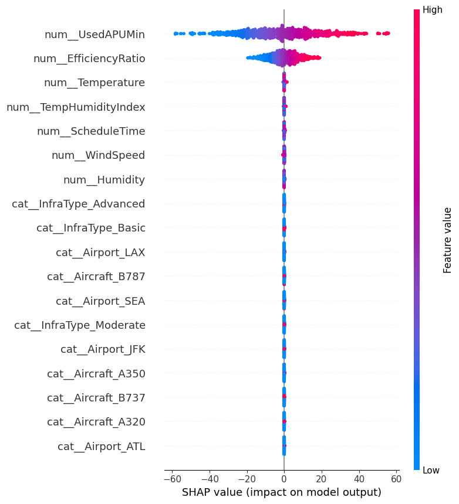

```python
import shap

pipe = Pipeline([('preprocessor', preprocessor), ('regressor', LGBMRegressor())])
pipe.fit(X_train, y_train)
X_transformed = pipe.named_steps['preprocessor'].transform(X_test)
explainer = shap.Explainer(pipe.named_steps['regressor'], X_transformed)
shap_values = explainer(X_transformed, check_additivity=False)

shap.summary_plot(shap_values, features=X_transformed,
                  feature_names=pipe.named_steps['preprocessor'].get_feature_names_out())
```

## Step 7: Hyperparameter Tuning

```python
from sklearn.model_selection import RandomizedSearchCV

param_grid = {
    'regressor__n_estimators': [50, 100, 150],
    'regressor__max_depth': [None, 10, 20, 30],
    'regressor__min_samples_split': [2, 5, 10]
}

pipe = Pipeline([('preprocessor', preprocessor), ('regressor', RandomForestRegressor())])
search = RandomizedSearchCV(pipe, param_grid, cv=3, n_iter=5, scoring='neg_mean_squared_error')
search.fit(X_train, y_train)

print("Best Parameters:", search.best_params_)
```

```
Best Parameters: {'regressor__n_estimators': 50, 'regressor__min_samples_split': 2, 'regressor__max_depth': 20}
```

## Step 8: Save and Load Model

```python
import joblib

joblib.dump(search.best_estimator_, 'best_rf_model.pkl')
loaded_model = joblib.load('best_rf_model.pkl')
loaded_model.predict(X_test[:5])
```

```
array([ 79.9948, 106.0574, 106.7454,  82.6164,  77.429 ])
```

## Step 9: Gradio Interface for Prediction

```python
import gradio as gr
import pandas as pd

# Custom theme with green primary color
theme = gr.themes.Base(
    primary_hue="green",
    neutral_hue="gray"
)

def predict_emission(aircraft, airport, temperature, humidity, windspeed, schedule_time, infra_type, apu_minutes):
    df_input = pd.DataFrame([{
        'Aircraft': aircraft,
        'Airport': airport,
        'Temperature': temperature,
        'Humidity': humidity,
        'WindSpeed': windspeed,
        'ScheduleTime': schedule_time,
        'InfraType': infra_type,
        'UsedAPUMin': apu_minutes,
        'EfficiencyRatio': apu_minutes / (apu_minutes + 1e-5),
        'TempHumidityIndex': temperature * humidity
    }])

    emission = loaded_model.predict(df_input)[0]

    miles_driven = emission / 0.404
    gallons_jetfuel = emission / 9.57
    trees_year = emission / 21

    return (
        f"Predicted Emissions: {emission:.2f} kg CO₂\n\n"
        f"🛣️ ~ {miles_driven:.0f} miles driven (gasoline car)\n"
        f"✈️ ~ {gallons_jetfuel:.1f} gallons of jet fuel burned\n"
        f"🌳 ~ Carbon absorbed by {trees_year:.1f} trees in 1 year"
    )

with gr.Blocks(theme=theme, css=".gradio-container { max-width: 100% !important; }") as demo:
    gr.Markdown("# EcoPower Emission Predictor")
    with gr.Row():
        with gr.Column(scale=1):
            temp = gr.Slider(0, 40, value=20, label="Temperature (°C)")
            hum = gr.Slider(10, 100, value=60, label="Humidity (%)")
            wind = gr.Slider(0, 30, value=10, label="Wind Speed (km/h)")
            time = gr.Slider(30, 180, value=90, label="Turnaround Time (min)")
            apu = gr.Slider(0, 90, value=40, label="APU Minutes Used")

        with gr.Column(scale=1):
            aircraft = gr.Dropdown(['A320', 'B737', 'A350', 'B787'], label="Aircraft Type")
            airport = gr.Dropdown(['JFK', 'LAX', 'SEA', 'ATL'], label="Airport")
            infra = gr.Dropdown(['Basic', 'Moderate', 'Advanced'], label="Infrastructure Type")
            submit = gr.Button("Submit")
            clear = gr.Button("Clear")

        with gr.Column(scale=1):
            output = gr.Textbox(label="Environmental Impact", lines=6)

    submit.click(
        predict_emission,
        inputs=[aircraft, airport, temp, hum, wind, time, infra, apu],
        outputs=output
    )

    clear.click(
        lambda: "",
        inputs=[],
        outputs=output
    )

demo.launch()
```

```
* Running on local URL:  http://127.0.0.1:7876
* To create a public link, set `share=True` in `launch()`.
```

[interactive chart not shown]

This interactive emissions predictor provides a concrete foundation for the EcoPower concept by showcasing how machine learning can intelligently estimate environmental impact based on real aircraft turnaround parameters. By translating raw APU data into meaningful sustainability metrics—such as equivalent miles driven or trees required to offset emissions—it demonstrates the technical insights necessary to optimize the APU. Earlier in the pipeline, various machine learning models—including Random Forest, Gradient Boosting, Ridge Regression, XGBoost, and LightGBM—were trained and evaluated to identify the most accurate and robust estimator for predicting CO₂ emissions. These models not only demonstrated high performance (with the best achieving low MAE and RMSE values), but also provided explainable outputs that informed feature importance and model behavior. Together, the trained ML models and interactive interface form a complete loop: data-driven prediction, real-time visualization, and actionable insight. With further development, these capabilities can be expanded into dynamic airport integrations, emissions monitoring dashboards, and predictive planning systems. This creates a strong technical foundation to help Boeing advance its carbon reduction strategies, optimize ground operations, and lead the next generation of sustainable aviation solutions.